# assignment1

Minjia ZHAO 7457981

2022-10-04

```r
library(tidyverse)
library(readxl)
library(readr)
```

# 1. Import the row data

Import the excel file and read each of its sheet.

```r
file_name <- "BIOL3207_Assignment1_DataFile.xlsx"
read_xlsx(file_name)
```

```
## # A tibble: 208 × 5
##    This is data from a decade-long ecological study ac…¹ ...2  ...3  ...4  ...5
##    <chr>                                                 <chr> <chr> <chr> <chr>
##  1 <NA>                                                  <NA>  <NA>  <NA>  <NA>
##  2 Individuals from two species, A fictus and A mendaci… <NA>  <NA>  <NA>  <NA>
##  3 <NA>                                                  <NA>  <NA>  <NA>  <NA>
##  4 Each row represents the data for a single animal.     <NA>  <NA>  <NA>  <NA>
##  5 <NA>                                                  <NA>  <NA>  <NA>  <NA>
##  6 Yes, some of these numbers are absurd! But, for the … <NA>  <NA>  <NA>  <NA>
##  7 <NA>                                                  <NA>  <NA>  <NA>  <NA>
##  8 Range (square km)                                     Weig… Heig… Spec… Year
##  9 61.5864471640255                                      19.1… 64.31 A fi… 2011
## 10 64.154590263497397                                    13.5… 28.23 A fi… 2011
## # … with 198 more rows, and abbreviated variable name
## #   ¹`This is data from a decade-long ecological study across five widely dispersed field sites.`
## # ℹ Use `print(n = ...)` to see more rows
```

```r
sheets <- excel_sheets(file_name)
sheets
```

```
## [1] "Field Site 1" "Field Site 2" "Field Site 3" "Field Site 4" "Field Site 5"
```

```r
read_xlsx(file_name,sheet=sheets[1])
```

```
## # A tibble: 208 × 5
##    This is data from a decade-long ecological study ac…¹ ...2  ...3  ...4  ...5
##    <chr>                                                 <chr> <chr> <chr> <chr>
##  1 <NA>                                                  <NA>  <NA>  <NA>  <NA>
##  2 Individuals from two species, A fictus and A mendaci… <NA>  <NA>  <NA>  <NA>
##  3 <NA>                                                  <NA>  <NA>  <NA>  <NA>
##  4 Each row represents the data for a single animal.     <NA>  <NA>  <NA>  <NA>
##  5 <NA>                                                  <NA>  <NA>  <NA>  <NA>
##  6 Yes, some of these numbers are absurd! But, for the … <NA>  <NA>  <NA>  <NA>
##  7 <NA>                                                  <NA>  <NA>  <NA>  <NA>
##  8 Range (square km)                                     Weig… Heig… Spec… Year
##  9 61.5864471640255                                      19.1… 64.31 A fi… 2011
## 10 64.154590263497397                                    13.5… 28.23 A fi… 2011
## # … with 198 more rows, and abbreviated variable name
## #   ¹`This is data from a decade-long ecological study across five widely dispersed field sites.`
## # ℹ Use `print(n = ...)` to see more rows
```

```r
read_xlsx(file_name,sheet=sheets[2])
```

```
## # A tibble: 200 × 5
##    `Range (square km)` `Weight (kg)` `Height (cm)` Species      Year
##                  <dbl>         <dbl>         <dbl> <chr>       <dbl>
##  1                52.9          18.1          73.0 A fictus     2011
##  2                64.9          24.6          83.0 A fictus     2011
##  3                63.9          20.7         104.  A mendacium  2011
##  4                70.7          20.5          79.0 A mendacium  2011
##  5                52.0          18.2          89.1 A fictus     2011
##  6                63.9          22.1          52.2 A fictus     2011
##  7                66.9          23.8          57.2 A mendacium  2011
##  8                65.4          22.2          71.4 A mendacium  2011
##  9                60.7          29.4          78.0 A fictus     2011
## 10                52.8          18.7          29.5 A fictus     2011
## # … with 190 more rows
## # ℹ Use `print(n = ...)` to see more rows
```

```r
read_xlsx(file_name,sheet=sheets[3])
```

```
## # A tibble: 200 × 5
##    `Range (square km)` `Weight (kg)` `Height (cm)` Species      Year
##                  <dbl>         <dbl>         <dbl> <chr>       <dbl>
##  1                72.4          28.8          39.3 A mendacium  2011
##  2                51.6          31.7          50   A fictus     2011
##  3                60.2          32.4          63.9 A mendacium  2011
##  4                65.0          31.6          91.6 A mendacium  2011
##  5                70.0          27.1          95.8 A mendacium  2011
##  6                51.3          35.6          46.1 A mendacium  2011
##  7                63.0          29.0          94.1 A fictus     2011
##  8                56.5          30.9          84.6 A fictus     2011
##  9                63.3          29.3          94.4 A mendacium  2011
## 10                46.7          27.5          79.4 A fictus     2011
## # … with 190 more rows
## # ℹ Use `print(n = ...)` to see more rows
```

```r
read_xlsx(file_name,sheet=sheets[4])
```

```
## # A tibble: 200 × 5
##    `Range (square km)` `Weight (kg)` `Height (cm)` Species      Year
##                  <dbl>         <dbl>         <dbl> <chr>       <dbl>
##  1                69.3          39.2          66.1 A fictus     2011
##  2                67.1          38.4          76.6 A fictus     2011
##  3                69.5          33.6          82.5 A fictus     2011
##  4                59.7          45.4          43.3 A fictus     2011
##  5                60.2          40.0          72.3 A fictus     2011
##  6                76.8          40.6          89.6 A mendacium  2011
##  7                63.3          43.6          52.9 A mendacium  2011
##  8                71.5          48.6         114.  A fictus     2011
##  9                72.5          34.4          68.1 A mendacium  2011
## 10                69.5          42.8          65.5 A mendacium  2011
## # … with 190 more rows
## # ℹ Use `print(n = ...)` to see more rows
```

```r
read_xlsx(file_name,sheet=sheets[5])
```

```
## # A tibble: 200 × 5
##    `Range (square km)` `Weight (kg)` `Height (cm)` Species      Year
##                  <dbl>         <dbl>         <dbl> <chr>       <dbl>
##  1                77.0          47.7          65.5 A mendacium  2011
##  2                64.0          52.6          59.2 A fictus     2011
##  3                70.7          55.9          54.7 A mendacium  2011
##  4                63.8          52.3          54.4 A fictus     2011
##  5                61.8          46.7          79.8 A fictus     2011
##  6                52.4          57.7          78.9 A fictus     2011
##  7                74.0          52.1          44.6 A mendacium  2011
##  8                78.6          49.5          92.4 A mendacium  2011
##  9                84.9          43.0          70.9 A mendacium  2011
## 10                64.8          45.5          71.7 A fictus     2011
## # … with 190 more rows
## # ℹ Use `print(n = ...)` to see more rows
```

# 2. Tidy the data name

We rename each sheet to make them tidy and integrate them into a new table containing all sites.Then we rename the column names and convert specifications, year and site, into the factor format.

```r
all_sites <- tibble()
for (Site in 1:length(sheets)){
   original_name <- paste("FieldSite",Site,sep = "_")
   call_name <- parse(text = original_name)
   if (Site == 1)
      do.call("<-",list(original_name, read_xlsx(file_name,sheet=sheets[Site], skip=8)))
   else
      do.call("<-",list(original_name, read_xlsx(file_name,sheet=sheets[Site])))
   do.call("<-",list(original_name, add_column(eval(call_name),Site)))
   all_sites <- bind_rows(all_sites, eval(call_name))
}

glimpse
```

```
## function (x, width = NULL, ...)
## {
##     UseMethod("glimpse")
## }
## <bytecode: 0x7fdc400f3ce0>
## <environment: namespace:pillar>
```

```r
colnames(all_sites) <- c("range","weight","height","species","year","site")
all_sites <- all_sites %>% mutate(species = as.factor(species),
                year = as.factor(year), site = as.factor(site))
```

# 3. Clean the missing value

Summarize the missing columns. Given that there are only two columns missed, we decided to delete them directly with little impact on the whole data set. Then we make a summary to all the data and find someone contract to the fact, such as weight less than 0, and filter those parts .

```r
summarise(all_sites,across(everything(), ~sum(is.na(.))))
```

```
## # A tibble: 1 × 6
##   range weight height species  year  site
##   <int>  <int>  <int>   <int> <int> <int>
## 1     1      0      0       1     0     0
```

```r
all_sites[!complete.cases(all_sites),]
```

```
## # A tibble: 2 × 6
##   range weight height species  year  site
##   <dbl>  <dbl>  <dbl> <fct>    <fct> <fct>
## 1  NA     15.7   43.4 A fictus 2014  2
## 2  60.2   40.0   53.7 <NA>     2018  4
```

```r
all_sites <- all_sites %>% drop_na()
```

Then we finish the split-apply-combine approach.

```r
summary(all_sites)
```

```
##      range           weight           height              species
##  Min.   :43.34   Min.   :-2.085   Min.   :  4.30   A fictus   :498
##  1st Qu.:58.22   1st Qu.:17.507   1st Qu.: 56.55   A mendacium:499
##  Median :62.97   Median :29.747   Median : 69.54   A Mendacium:  1
##  Mean   :63.57   Mean   :29.861   Mean   : 69.55
##  3rd Qu.:68.59   3rd Qu.:42.735   3rd Qu.: 82.68
##  Max.   :89.20   Max.   :58.610   Max.   :145.76
##
##       year     site
##  2011   :100   1:200
##  2012   :100   2:199
##  2013   :100   3:200
##  2015   :100   4:199
##  2016   :100   5:200
##  2019   :100
##  (Other):398
```

```r
filter(all_sites, weight <= 0)
```

```
## # A tibble: 4 × 6
##   range weight height species     year  site
##   <dbl>  <dbl>  <dbl> <fct>       <fct> <fct>
## 1  52.4 -0.762   59.2 A fictus    2012  1
## 2  68.2 -1.20    93.2 A mendacium 2016  1
## 3  74.7 -2.09    70.0 A mendacium 2016  1
## 4  68.8 -1.89    98.9 A fictus    2017  1
```

```r
table(all_sites$year)
```

```
##
## 2011 2012 2013 2014 2015 2016 2017 2018 2019 2020 2217
##  100  100  100   99  100  100   99   99  100  100    1
```

```r
levels(all_sites$species) <- c('A fictus','A mendacium','A mendacium')
levels(all_sites$year)[11] <- "2017"
```

```r
write.csv(all_sites,"./u7457981_Assignment1_DataFile.csv")
```

# 4. Use plots to manage the visualization.

First we use ggplot to distinguish the difference of their traits between different sites and years. It turns out that the the range of data in “A fictus” did not show significant differences between sites and years. In contrast, in “A mendacium”, this variation was shown between sites, while there was no significant difference between years. Regardless of the species, the mean values of the weights were different between sites.No differences in height were evident.

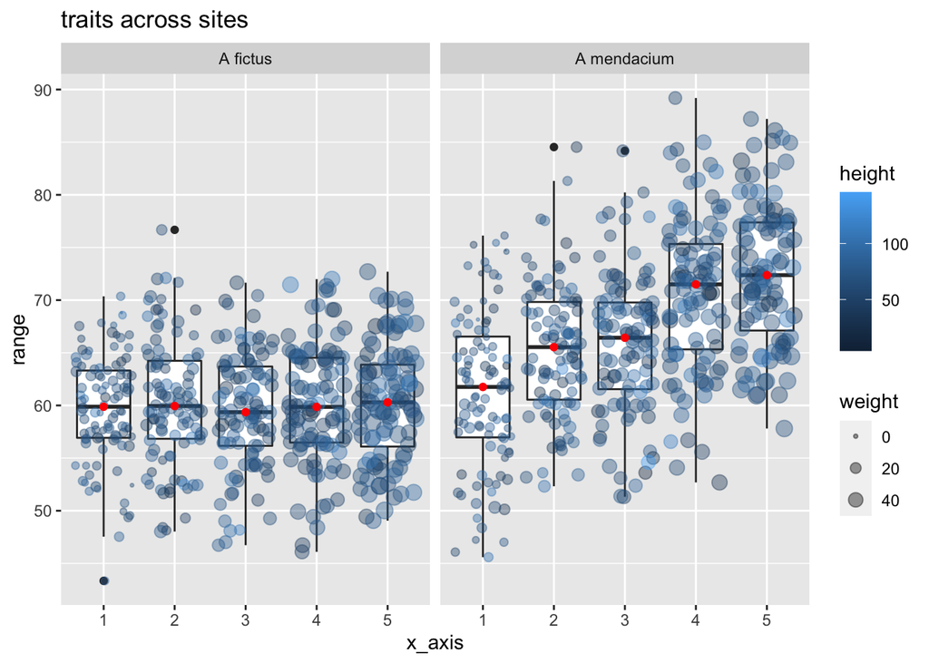

```r
colour_bar <- function(plot_data,x_axis){
  ggplot(data = plot_data ,aes(x = x_axis, y = range)) + geom_boxplot()+
  geom_jitter(alpha=0.4, aes(size = weight, color = height)) + scale_size(range = c(0, 4))+
  stat_summary(fun = median, colour = "red", geom = "point") + facet_wrap(~species)
    }
colour_bar(all_sites,with(all_sites,site)) + ggtitle("traits across sites")
```

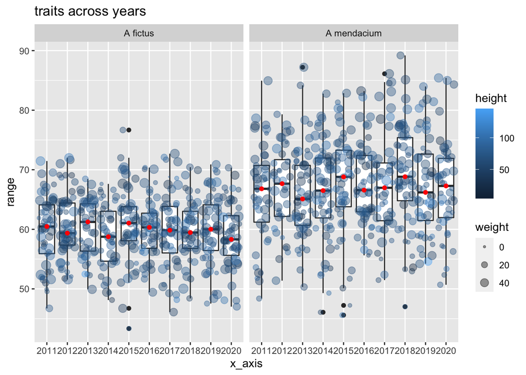

```r
colour_bar(all_sites,with(all_sites,year)) + ggtitle("traits across years")
```

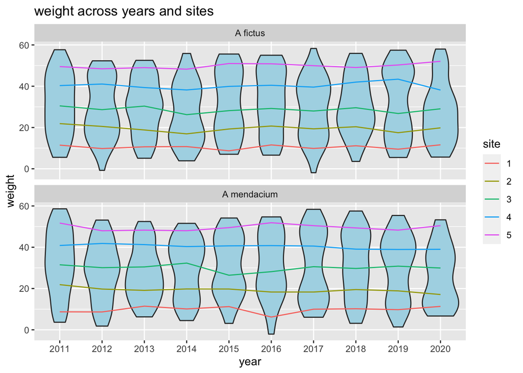

```r
mean_weight <- all_sites %>% select(weight,species,year,site) %>%
      group_by(species,year,site) %>% summarise(weight = mean(weight),.groups = "drop")
all_sites %>% ggplot(aes(x = year, y = weight))+ geom_violin(fill = "light blue") +geom_line(data = mean_weight, aes(group = site,colour = site)) + facet_wrap(~species,nrow =  2)  + ggtitle("weight across years and sites")
```

Then we use ggplot to help analyze the distribution of value in different variables, comparing with each other and find the relationship. Clearly the distribution of weight didn’t show difference between species and the minimum range of height may show a little variation: “A fictus” has higher minimum height.

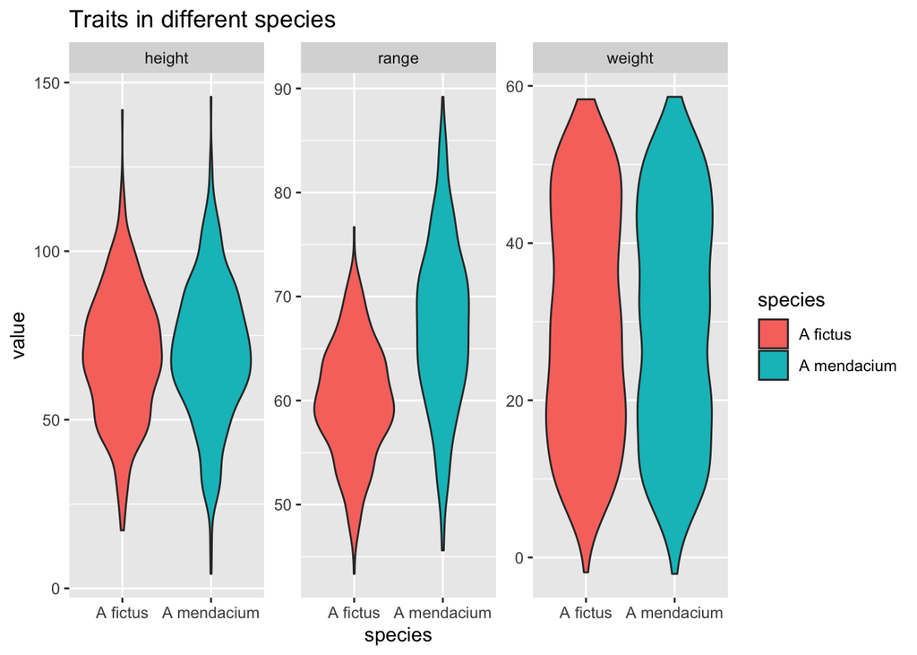

```r
species_trait <- all_sites %>% pivot_longer(cols = c(range,height,weight), names_to = "trait", values_to = "value")
species_trait %>% ggplot(aes(x = species, y = value)) + geom_violin(aes(fill = species)) +
   facet_wrap(~trait, scales = "free")+
   ggtitle("Traits in different species")
```

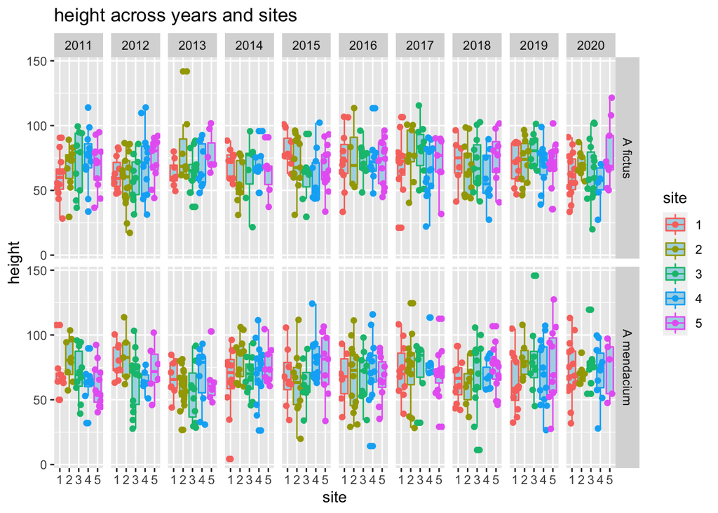

```r
all_sites %>% ggplot(aes(x = site,y = height, colour = site))+ geom_boxplot(fill="light blue") +
        geom_jitter() + facet_grid(species~year) + ggtitle("height across years and sites")
```

And so on to the different characteristics(trait) of different species. The range and weight of “A mendacium” have a linear relationship in each site, opposite with “A fictus”.

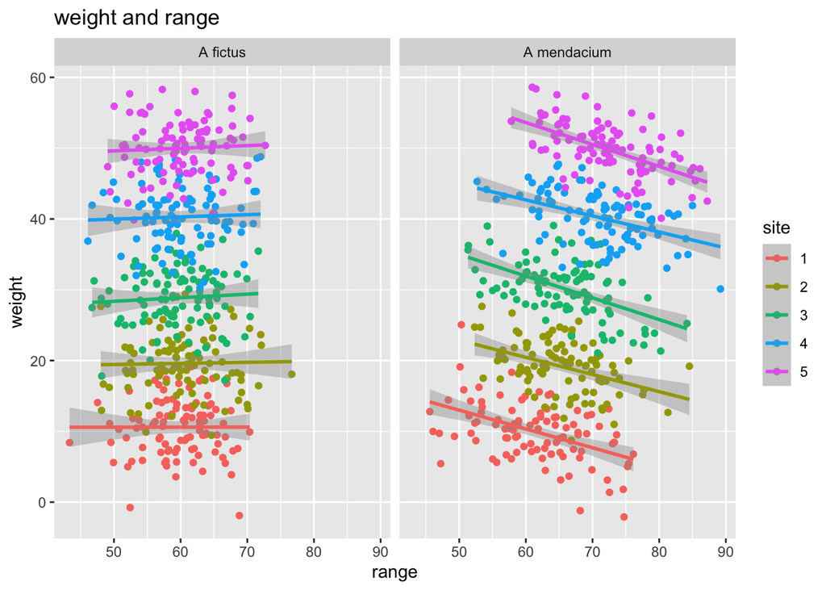

```r
  all_sites %>% ggplot(aes(x = range,y = weight, colour = site))+ geom_point() +
        geom_smooth(method = lm,formula = y~x) + facet_wrap(~species) + ggtitle("weight and range")
```

# 5. Communication

### *Hypothesis 1:“A mendacium” has differences in the range of different sites.*

### *Hypothesis 2: The weight difference between two species is not significant, though obvious between different sites.*

We will use t-test and ANOVA test to deal with hypothesis 1, and also ANOVA test to hypothesis 2.

```r
t_test <- species_trait %>% group_by(trait) %>% summarise(broom::tidy(t.test(value~species, data = cur_data())), .groups = "drop") %>%
   select(-parameter,-method,-alternative) %>% rename(t_value = statistic, diff_name = estimate, mean1 = estimate1, mean2 = estimate2)
knitr::kable(t_test,caption = "T-test for different traits")
```

T-test for different traits

| trait | diff_name | mean1 | mean2 | t_value | p.value | conf.low | conf.high |
| --- | --- | --- | --- | --- | --- | --- | --- |
| height | -1.2171295 | 68.94263 | 70.15976 | -0.9669613 | 0.3337994 | -3.687185 | 1.252926 |
| range | -7.1787445 | 59.97643 | 67.15517 | -16.5915652 | 0.0000000 | -8.027922 | -6.329567 |
| weight | 0.0131248 | 29.86731 | 29.85419 | 0.0140731 | 0.9887745 | -1.816986 | 1.843236 |

```r
ANOVA_test_range <- all_sites %>% select(species,year,range,site) %>% group_by(species) %>%
    summarise(broom::tidy(aov(range~site + year,data = cur_data())), .groups = "keep")
knitr::kable(ANOVA_test_range,caption = "ANOVA test for each species between different years")
```

ANOVA test for each species between different years

| species | term | df | sumsq | meansq | statistic | p.value |
| --- | --- | --- | --- | --- | --- | --- |
| A fictus | site | 4 | 46.57706 | 11.64426 | 0.3752455 | 0.8263311 |
| A fictus | year | 9 | 166.98193 | 18.55355 | 0.5979026 | 0.7990709 |
| A fictus | Residuals | 484 | 15019.03068 | 31.03106 | NA | NA |
| A mendacium | site | 4 | 7878.34231 | 1969.58558 | 41.4074099 | 0.0000000 |
| A mendacium | year | 9 | 357.43138 | 39.71460 | 0.8349364 | 0.5841292 |
| A mendacium | Residuals | 486 | 23117.08444 | 47.56602 | NA | NA |

```r
ANOVA_test_weight <- all_sites %>% select(species,year,weight,site) %>% group_by(species) %>%
    summarise(broom::tidy(aov(weight~site + year,data = cur_data())), .groups = "keep")
knitr::kable(ANOVA_test_weight,caption = "ANOVA test for each species between weight")
```

ANOVA test for each species between weight

| species | term | df | sumsq | meansq | statistic | p.value |
| --- | --- | --- | --- | --- | --- | --- |
| A fictus | site | 4 | 98952.4626 | 24738.11565 | 1474.7522551 | 0.0000000 |
| A fictus | year | 9 | 227.4961 | 25.27734 | 1.5068978 | 0.1423911 |
| A fictus | Residuals | 484 | 8118.8199 | 16.77442 | NA | NA |
| A mendacium | site | 4 | 101456.8821 | 25364.22053 | 1695.1996694 | 0.0000000 |
| A mendacium | year | 9 | 114.8126 | 12.75695 | 0.8526017 | 0.5679059 |
| A mendacium | Residuals | 486 | 7271.7164 | 14.96238 | NA | NA |

# Conclusion:

### *1. There are significant differences between the two species in range.(p value is less than 0.05).There are significant differences in range between different sites in “A mendacium”, but similar bewteen different years.*

### *2. Both species show significant differences in weight between different sites.*